# Effects of E protein substitutions

Angkana T. Huang

2021-10-22

# AA diversity along the polyprotein

Variations are low in most positions. Below shows the distribution of variations along the polyprotein.

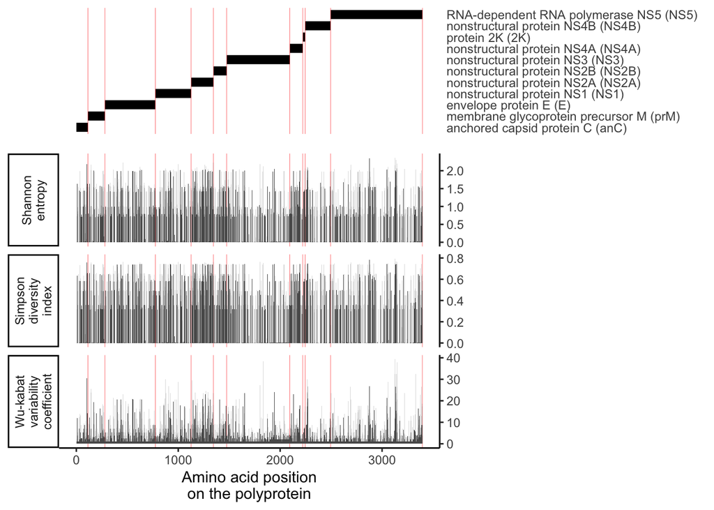

# E protein

394 nonzero effect substitutions, residing on 77 sites, showed nonzero effect in at least 95% of the 100 estimations. Distribution of % Variance explained across the 100 estimations are shown below.

```
##         intercept    slope corr Rsq.all Rsq.inter Rsq.intra
## 0%    -0.05011018 1.005677 0.87    50.5      26.0      79.1
## 2.5%  -0.04773141 1.005766 0.87    50.6      26.1      79.1
## 50%   -0.04329257 1.007237 0.87    50.7      26.2      79.2
## 97.5% -0.03672735 1.008132 0.87    50.8      26.4      79.2
## 100%  -0.03586230 1.008739 0.87    50.9      26.5      79.3
```

## Inferred effects vs known epitopes

Number of monoclonal antibodies compiled in the DENVab database.

```
## [1] 253
```

Of these, a subset were shown to have neutralization activity.

```
## [1] 70
```

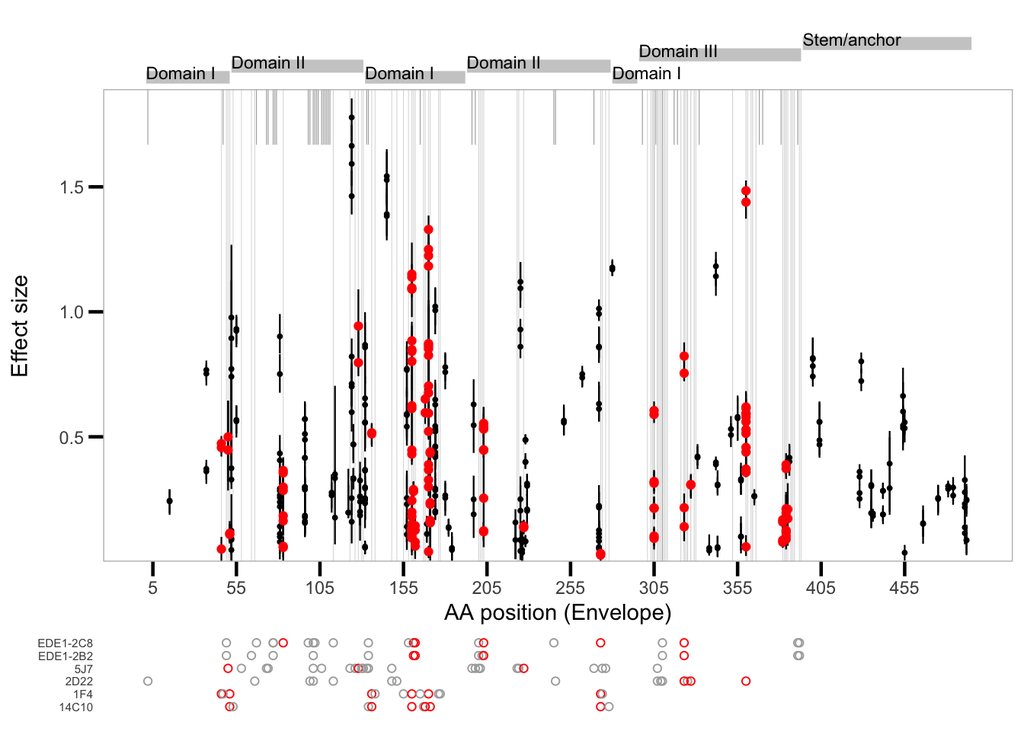

Contigency table of known epitopes vs observed variations in the dataset.

```
## , , diversity = has diversity
##
##           mAb_database
## effect     known epitopes not epitopes/unknown
##   non-zero             22                   55
##   zero                 52                  166
##
## , , diversity = no diversity
##
##           mAb_database
## effect     known epitopes not epitopes/unknown
##   non-zero              0                    0
##   zero                 37                  163
```

Odds ratio of being picked up by the model

```r
exp(coef(fit)[2,1] + zCI * coef(fit)[2,2]) %>% round(2) # odds ratio, 95%CI
```

```
##  2.5%   50% 97.5%
##  0.71  1.28  2.29
```

## Off diagonals of the contingency table

Number of epitopes that were missed (although there was variability in the data) that were within N sites from nonzero effect sites.

```
##   N nMissed nProximal propProximal
## 1 0      52         0    0.0000000
## 2 1      52        22    0.4230769
## 3 2      52        34    0.6538462
## 4 3      52        41    0.7884615
## 5 4      52        43    0.8269231
## 6 5      52        44    0.8461538
```

Probability of observing greater than or equal to this number of overlap between nonzero effect sites and epitope regions (with the given the expansion window size).

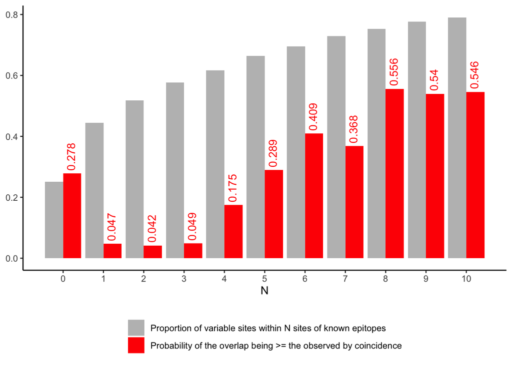

```
##     N nIntersect nEpitopeSite propEpitopeSite     propGe
## 1   0         22           74       0.2508475 0.27804757
## 2   1         42          131       0.4440678 0.04731379
## 3   2         48          153       0.5186441 0.04164642
## 4   3         52          170       0.5762712 0.04873758
## 5   4         52          182       0.6169492 0.17481921
## 6   5         54          196       0.6644068 0.28932826
## 7   6         55          205       0.6949153 0.40909838
## 8   7         58          215       0.7288136 0.36828657
## 9   8         58          222       0.7525424 0.55552316
## 10  9         60          229       0.7762712 0.53972647
## 11 10         61          233       0.7898305 0.54599044
```

Number of non-epitope sites with nonzero effect that were close to epitope sites that were not detected

```
##   delta numNonzero.fromEpitopeZero numNonzero.fromEpitope
## 1     1                         16                     20
## 2     2                         24                     26
## 3     3                         27                     30
```

Where are the nonzero effect sites that were in the anchor/stem domain?

```
##  [1] 404 446 491 475 484 442 435 455 436 400 466 428 429 481 454 492
```

## Estimated effect sizes

|  | Position | Substitution | Effect.median | Effect.lower | Effect.upper |
| --- | --- | --- | --- | --- | --- |
| 1 | 15 | l15i | 0.241724950987774 | 0.187665231954958 | 0.289798239023558 |
| 2 | 15 | i15l | 0.244429842878936 | 0.194776369138559 | 0.289803711301775 |
| 3 | 37 | s37g | 0.361448567039792 | 0.311644590585711 | 0.394554340489545 |
| 4 | 37 | g37s | 0.371852925877129 | 0.328041039121303 | 0.407893984196379 |
| 5 | 37 | d37n | 0.752452264905942 | 0.705045789930101 | 0.790231889971396 |
| 6 | 37 | n37d | 0.767319216819624 | 0.723962875339227 | 0.805155102095287 |
| 7 | 46 | i46t | 0.0507955967244614 | 0.0012269880664737 | 0.0994526052620224 |
| 8 | 46 | l46i | 0.456816566018318 | 0.420956551131718 | 0.489543422810902 |
| 9 | 46 | i46l | 0.473147712904655 | 0.435041836616201 | 0.503014279391138 |
| 10 | 50 | a50v | 0.446999046122615 | 0.285067773636942 | 0.642781352345265 |

[output cut: 384 more lines]